# 21_reach_residence

Markus Min

2023-04-09

### Description

This Rmd file investigates residence time of individual fish in different reaches to determine a time at which a “decision” is made on movement (similar to Siegel et al. 2021).

### Proposed covariate structure

##### Continuous

1. Temperature
1. In mainstem sites, use the temperature value at the median residence time of “fast” fish - the fish that move straight through
2. Use temperature as a covariate for every movement out of the mainstem (upstream, downstream, or into tributaries)
2. Spill
1. March days of spill
2. Use this as a covariate for fallback only; might need to do some clever indexing with origins to make this happen
3. Flow - DROP. Flow is highly correlated with spill, and spill has been found to be more informative than flow for downstream movements (fallback) and not a good predictor of upstream movements
1. Richins and Skalski (2018) investigated how fallback rates were related to flow, and found no relationship between fallback rates to natal tributaries and late-winter flow
2. Siegel et al. (2021) looked at upstream migration of Steelhead (between Bonneville and McNary) and found that flow was not a good predictor for upstream migratory delays

##### Categorical

1. Natal origin - all movements within ESU boundaries
2. Hatchery vs. wild - all movements
3. Barged vs. not barged - all movements
1. Note that Richins and Skalski (2018) found that barging led to lower migration success (but also lower overshooting), but only had enough data for Tucannon River Hatchery Steelhead
4. Acclimated vs. not acclimated - all movements
5. Ocean age - all movements

Inevitably we are going to have fish where we are using covariates where we know they didn’t experience those conditions. If its only off by a few days it shouldn’t be a big deal because conditions are generally very autocorrelated, especially in the case of things like temperature.

### Lower/Middle Columbia

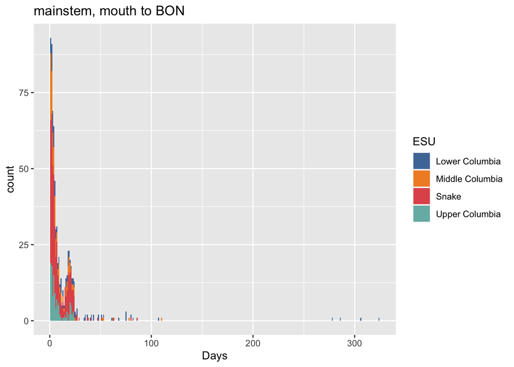

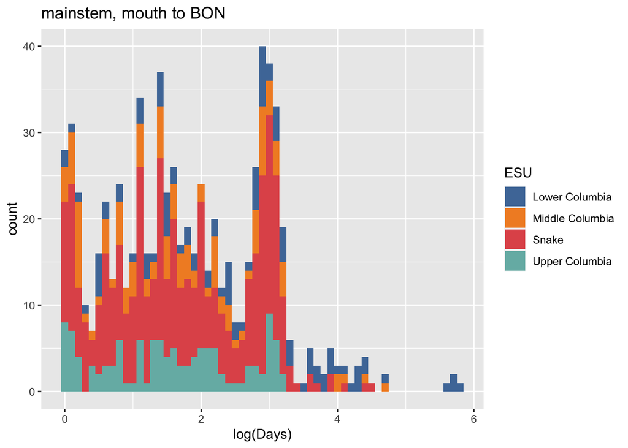

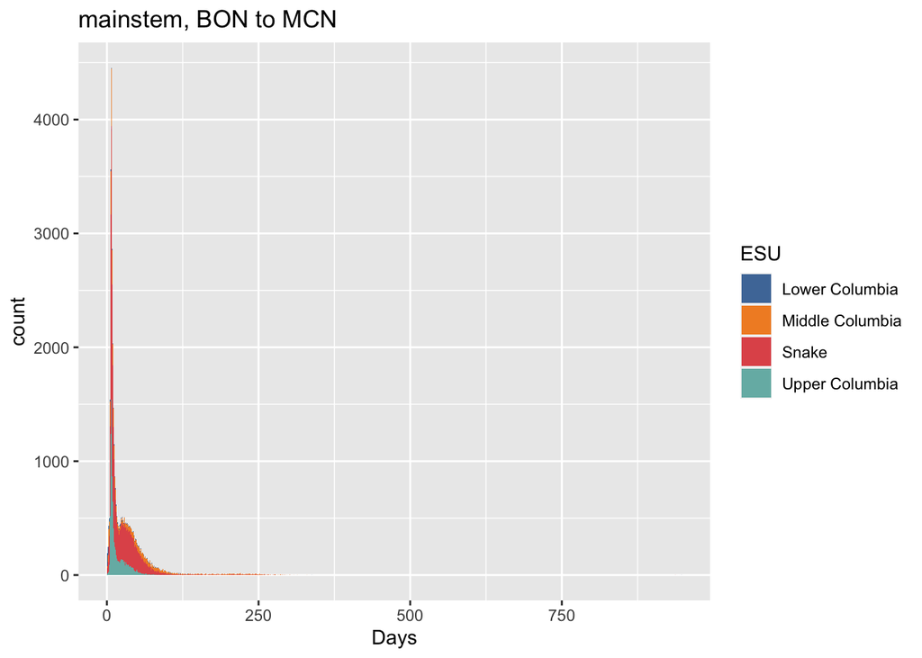

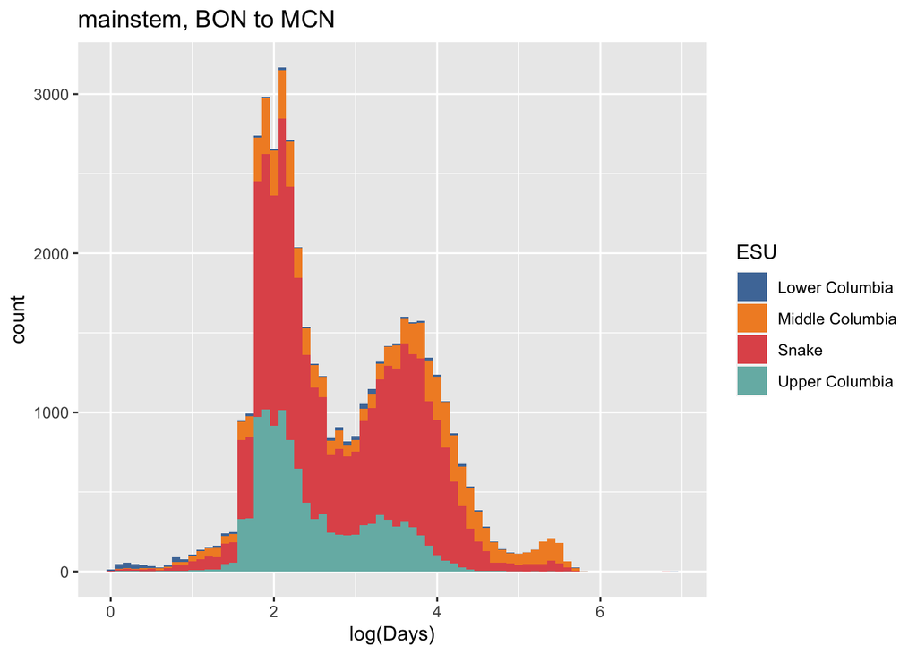

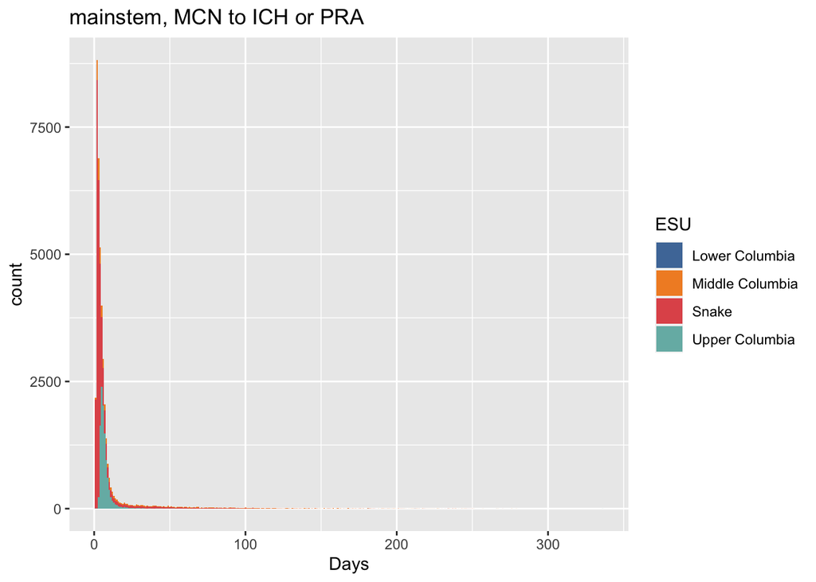

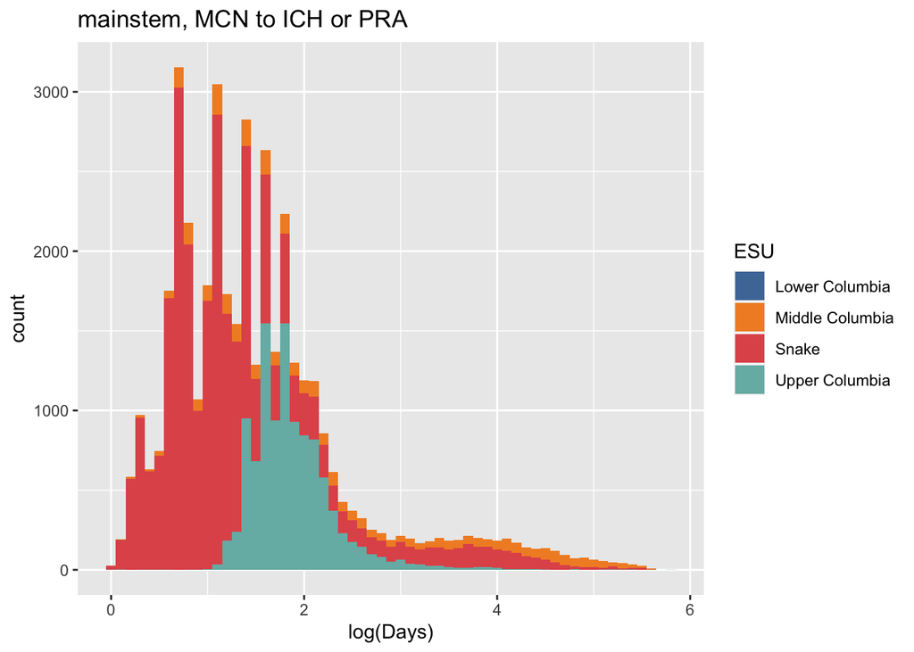

### Upper Columbia

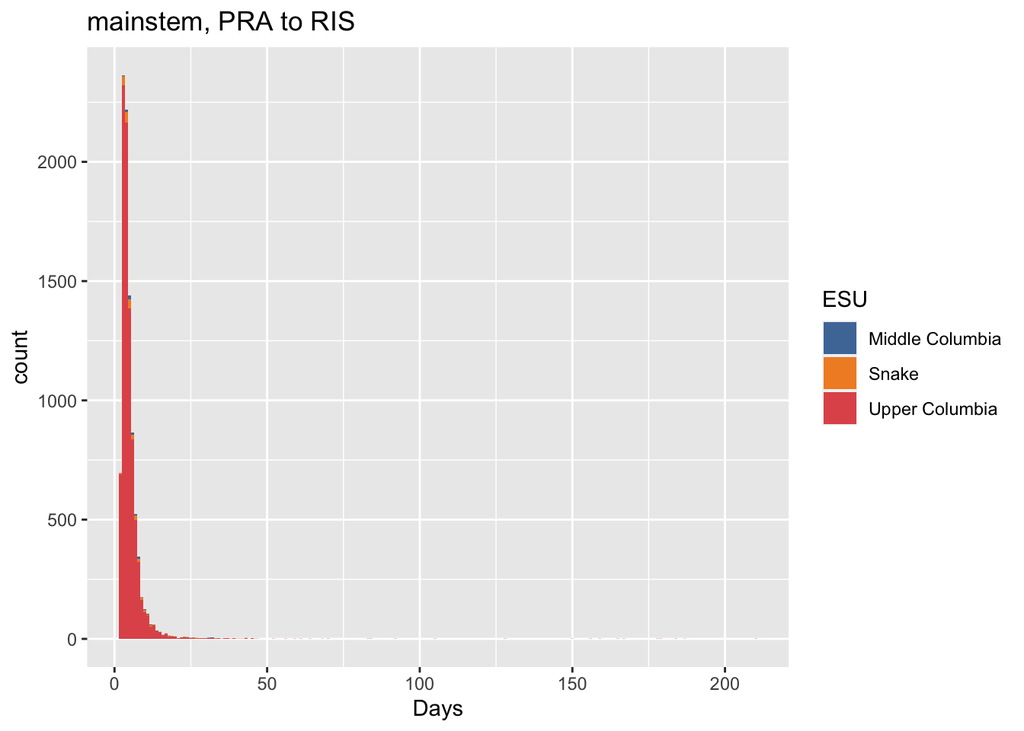

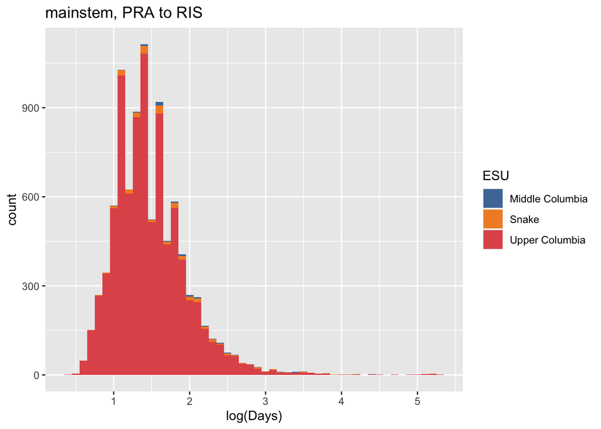

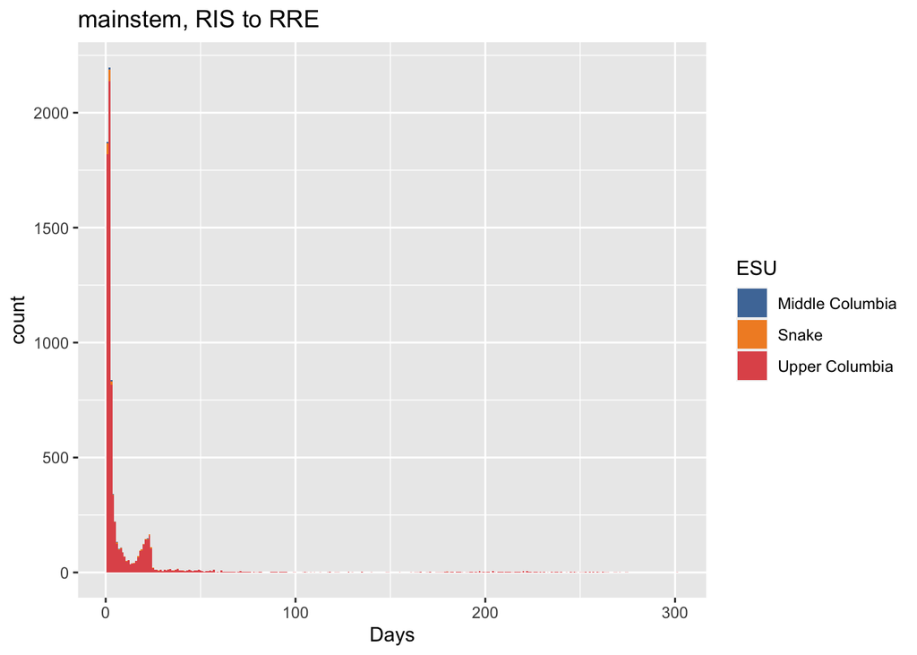

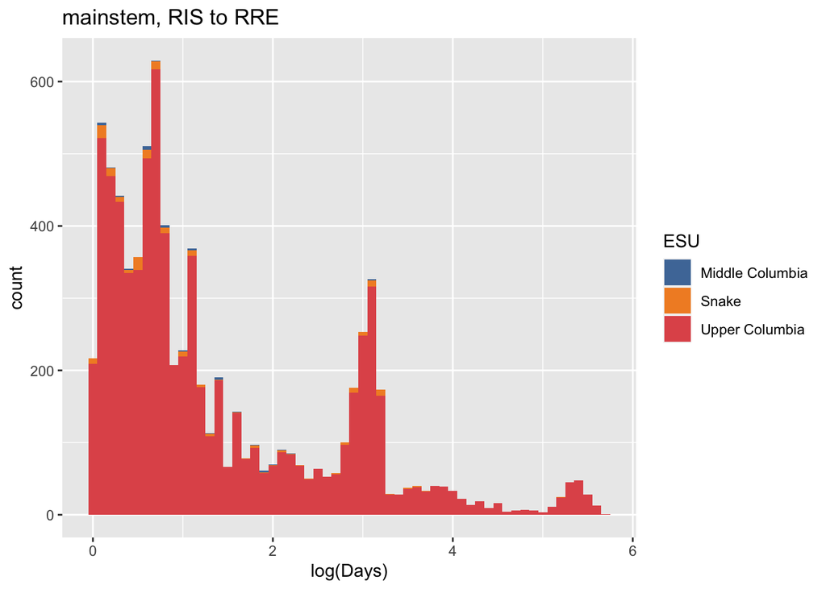

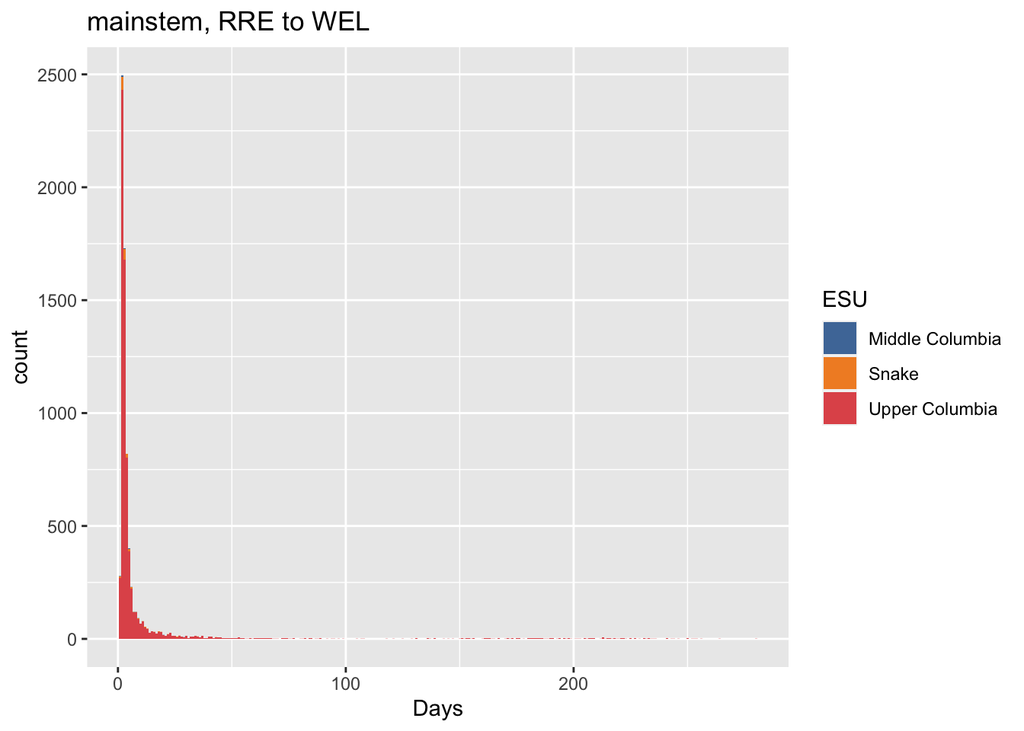

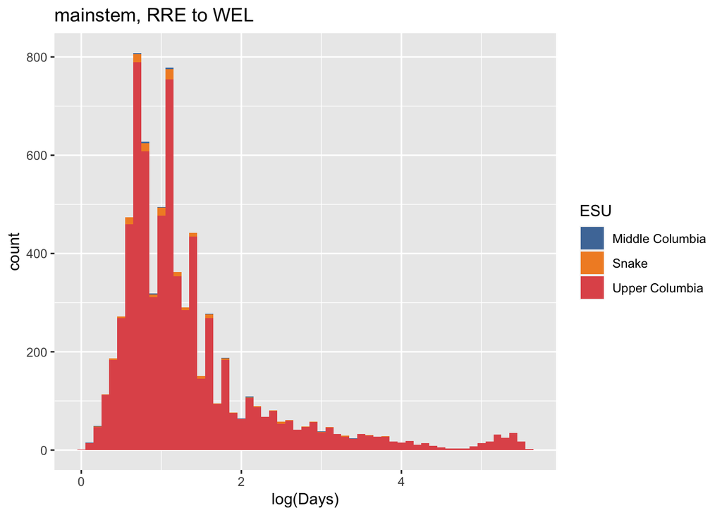

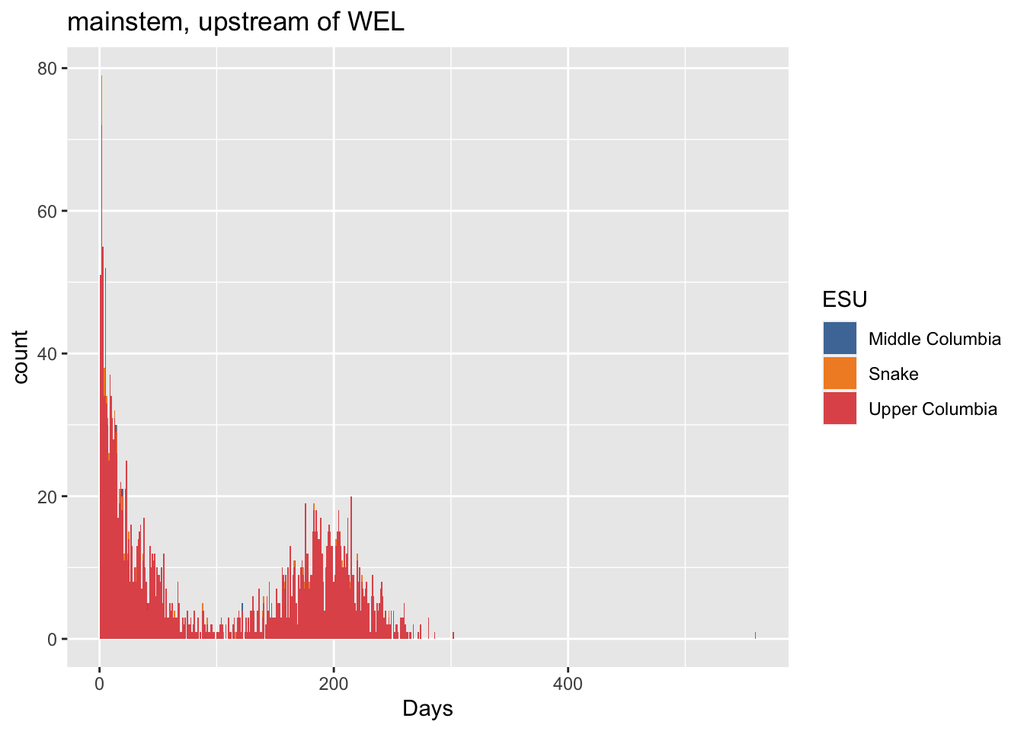

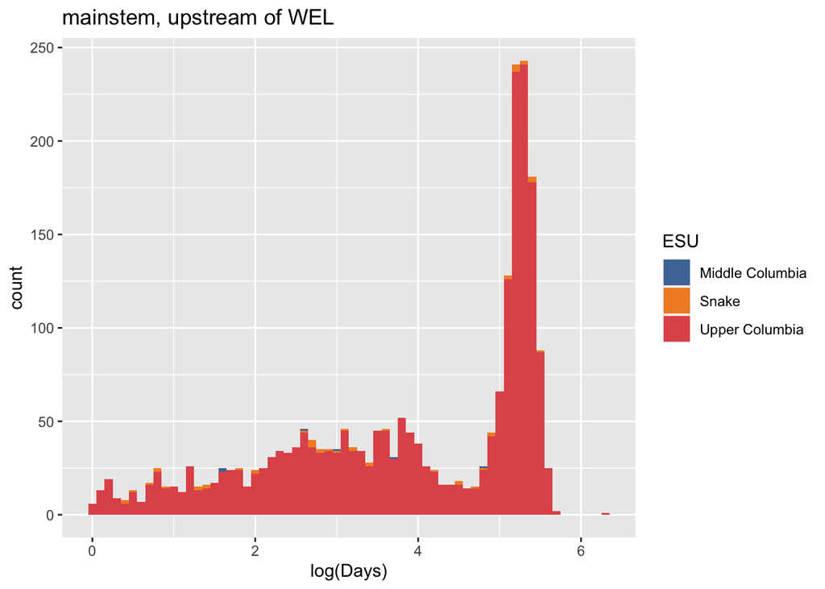

### Snake

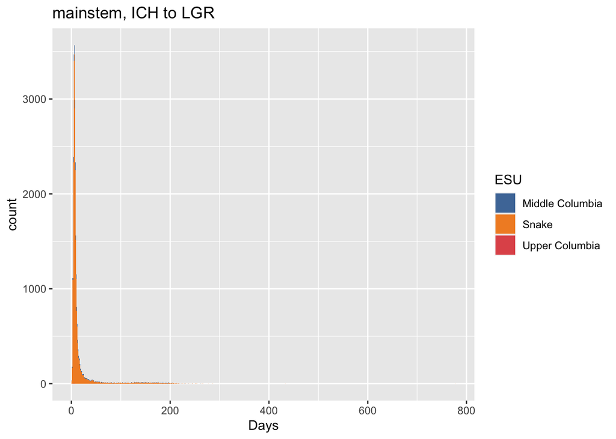

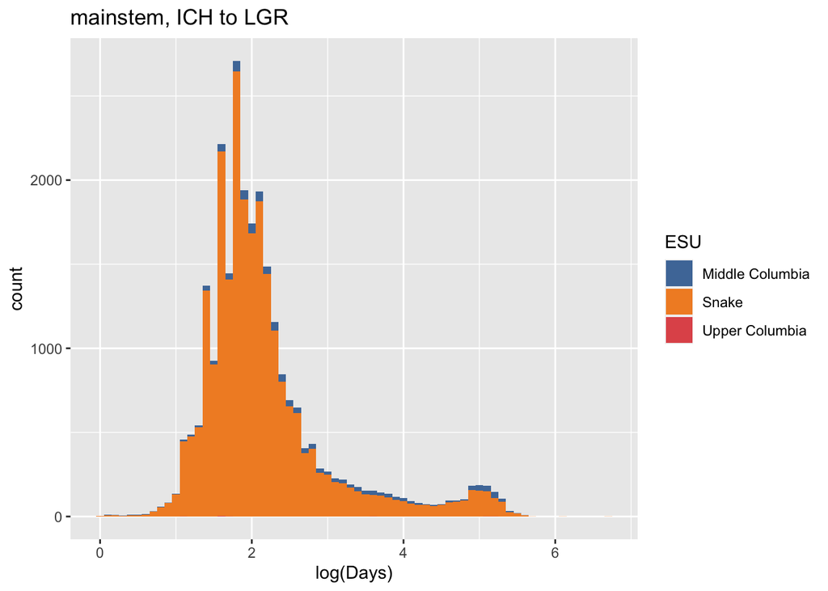

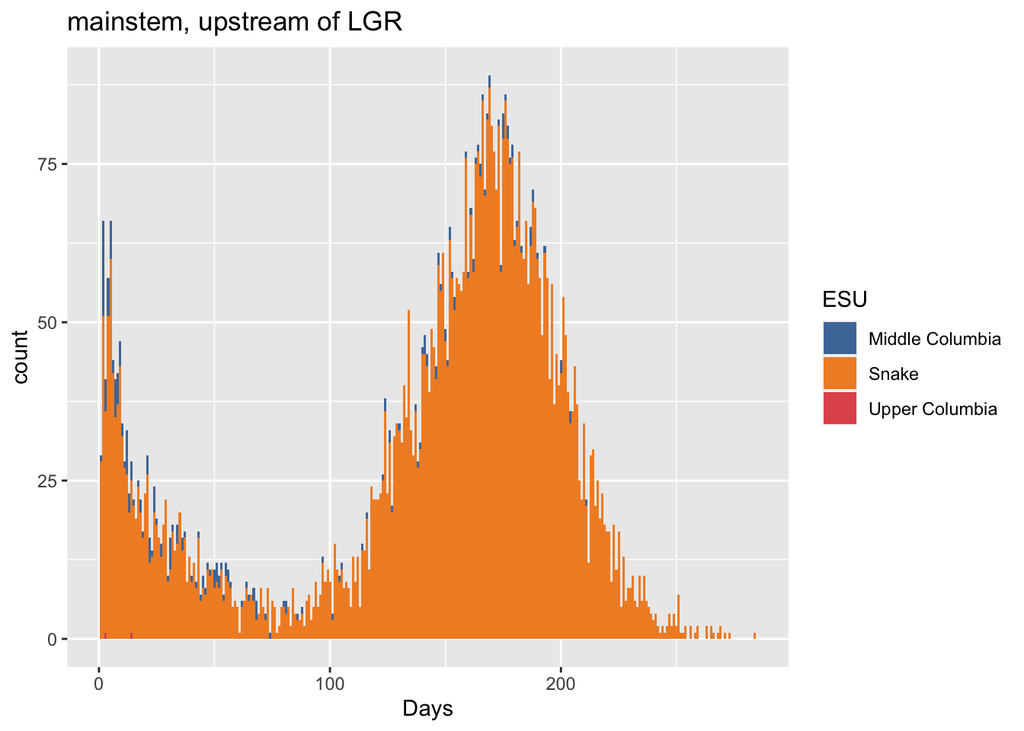

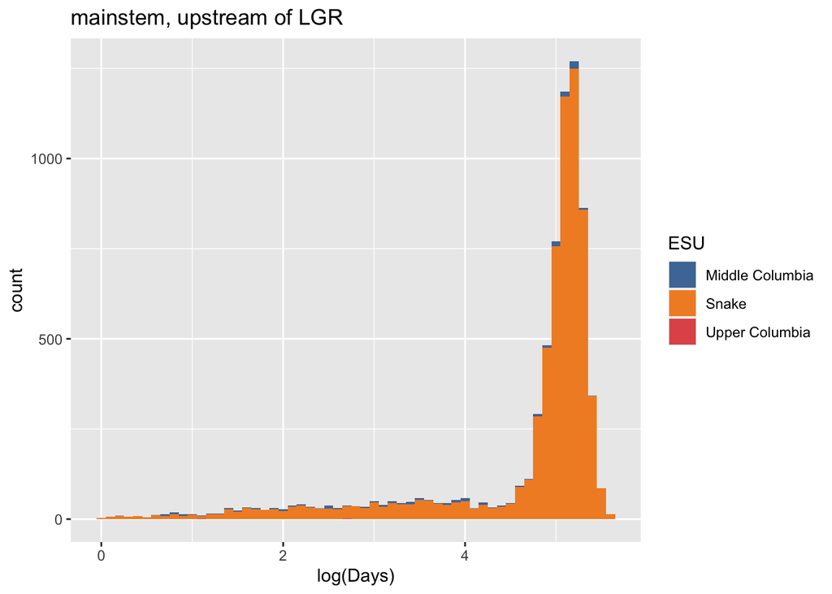

## Covariate data exploratory analysis

What is the relationship between water temperature at Ice Harbor and the probability of overshooting (and other movements) for Walla Walla River Steelhead?

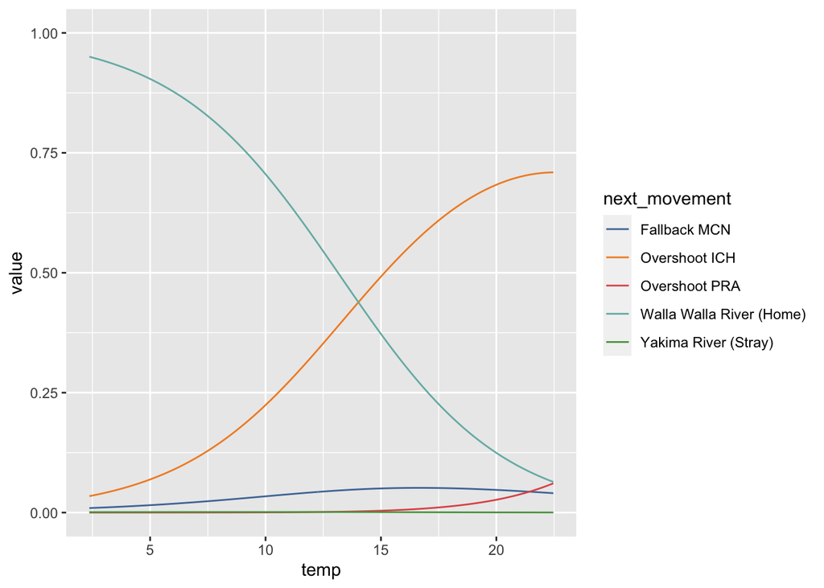

##### Okay, but how is temperature correlated with direction of movement?

The temperatures for fish going *upstream* are as follows:

```
##    Min. 1st Qu.  Median    Mean 3rd Qu.    Max.
##   2.917  16.896  19.256  18.173  20.763  22.473
```

The temperatures for fish going *downstream* are as follows: 2.36725, 6.673875, 11.65325, 12.8412612, 19.6848125, 22.38575.

```
##    Min. 1st Qu.  Median    Mean 3rd Qu.    Max.
##   2.367   6.674  11.653  12.841  19.685  22.386
```

#### run the multinomial logit again with fish, but now only those going upstream

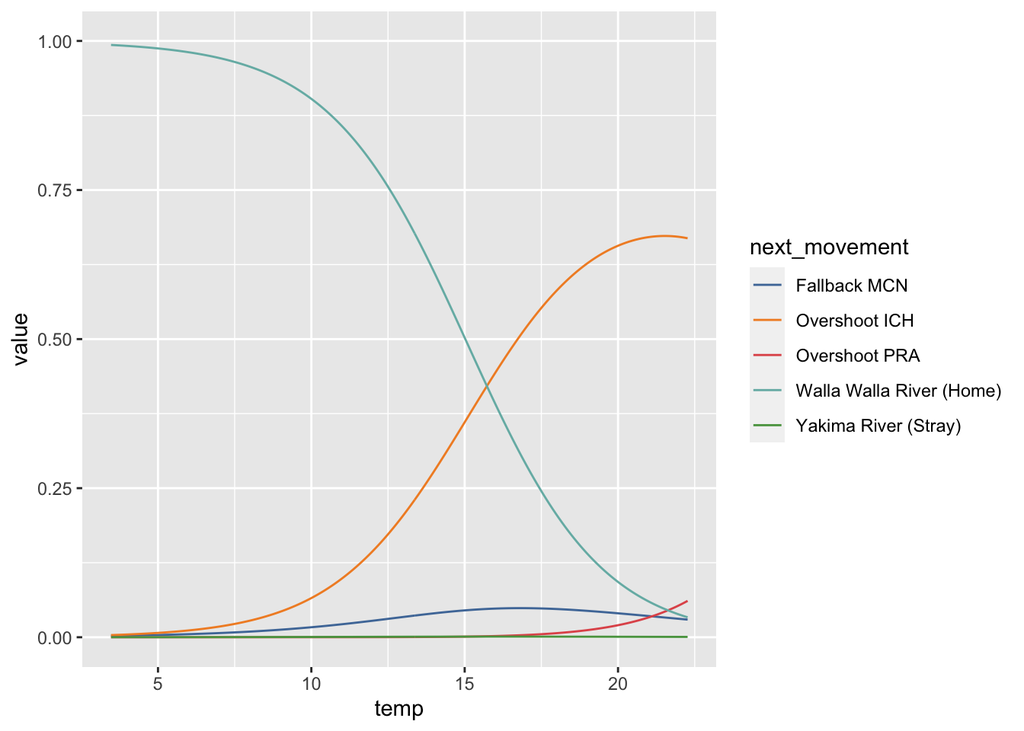

#### run the multinomial logit again with fish, but now only those going downstream

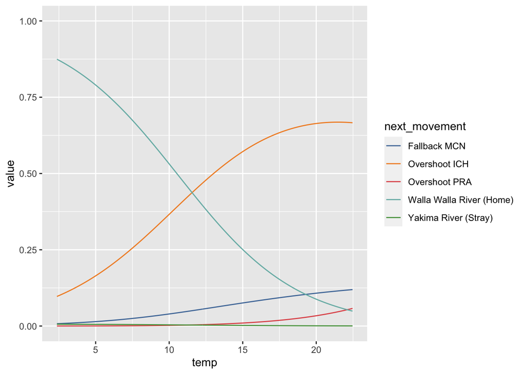